# Statical rethinking notes

Anna-Leigh Brown

11/03/2021

# Chapter 3

This is how to generate samples from a grid posterior

```r
water = 6
tosses = 9
p_grid = seq(from = 0, to = 1, length.out = 1000)
prob_p = rep(1, 1000)

prob_data = dbinom(water, tosses, prob = p_grid)
posterior = prob_data * prob_p
posterior = posterior / sum(posterior)
```

Now we’ll sample 10,000 times from the posterior

```r
samples = sample(p_grid, prob = posterior, size = 1e4, replace = T)
```

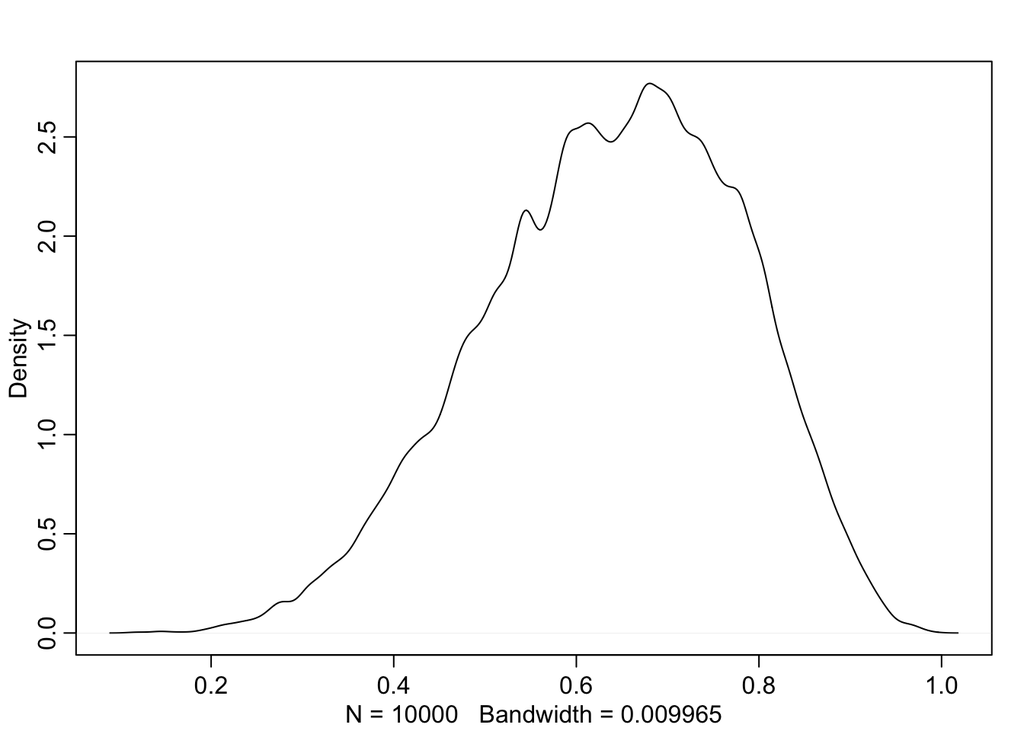

```r
dens(samples)
```

## Intervals of defined boundaries

What’s the posterior probability that the true proportion of water is less than 50%?

With our grid approximation we can simply sum up all the probability where that’s true

```r
sum(posterior[p_grid < 0.5])
```

```
## [1] 0.1718746
```

```r
sum(samples < 0.5) / 1e4
```

```
## [1] 0.1724
```

Using the same approach you can ask how much posterior probability lies between 0.5 and 0.75?

```r
sum( samples > 0.5 & samples < 0.75) / 1e4
```

```
## [1] 0.5944
```

To define the boundaries of the lower 80% posterior probabilities we can use quantile funciton

```r
quantile( samples, 0.8)
```

```
##       80%
## 0.7647648
```

```r
quantile( samples , c( 0.1 , 0.9 ) )
```

```
##       10%       90%
## 0.4474474 0.8128128
```

But that only works when the tails of our posterior aren’t skewed, what about data like this which is?

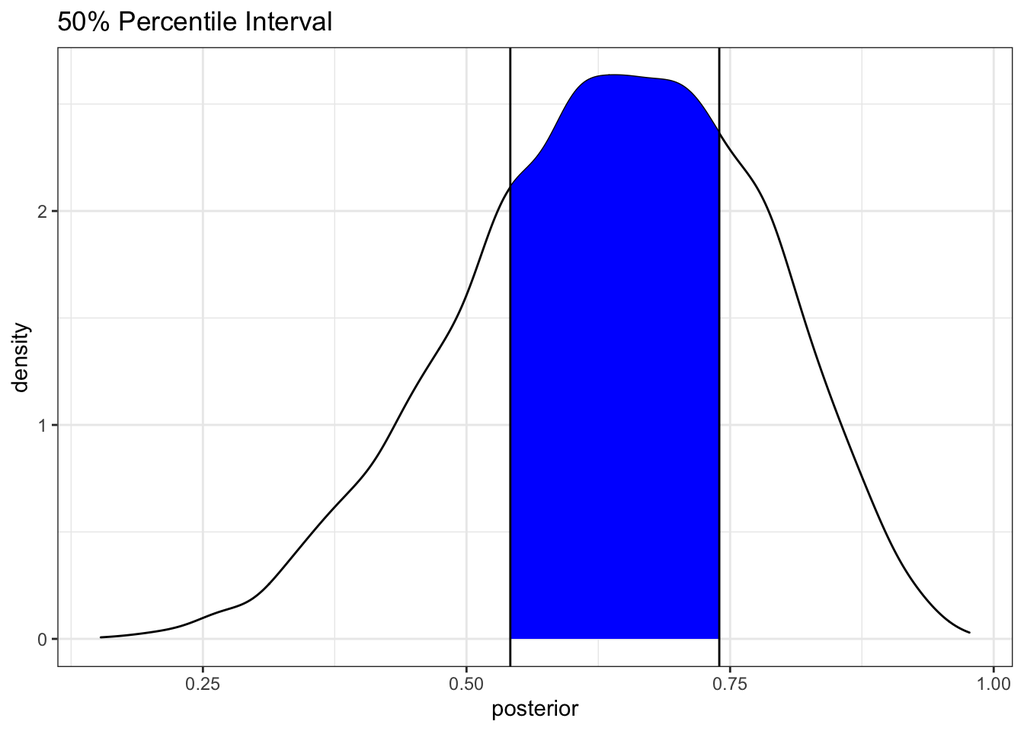

```r
p_grid <- seq( from=0 , to=1 , length.out=1000 )
prior <- rep(1,1000)
likelihood <- dbinom( 6 , size=9 , prob=p_grid )
posterior <- likelihood * prior
posterior <- posterior / sum(posterior)
samples <- sample( p_grid , size=1e4 , replace=TRUE , prob=posterior )
post = tibble(posterior = samples)
x.dens <- density(post$posterior)
df.dens <- data.frame(x = x.dens$x, y = x.dens$y)
pct_interval = PI( samples , prob=0.5 )
ggplot(data = post) + theme_bw() +
    geom_density(aes(x=posterior, y = ..density..), color = 'black') +
    geom_area(data = subset(df.dens, x >= pct_interval[1] & x <= pct_interval[2]),
              aes(x=x,y=y), fill = 'blue') +
    geom_vline(xintercept = pct_interval[1])  +
    geom_vline(xintercept = pct_interval[2])  +
    ggtitle('50% Percentile Interval')
```

On the other hand we can plot the highest posterior density interval. The HPDI is the narrowest inteval containing the specfied probability mass.

There is afteral an infinite number of intervals containing the same mass, but we want the interval that best represents teh parameter values that is most consistent with the data.

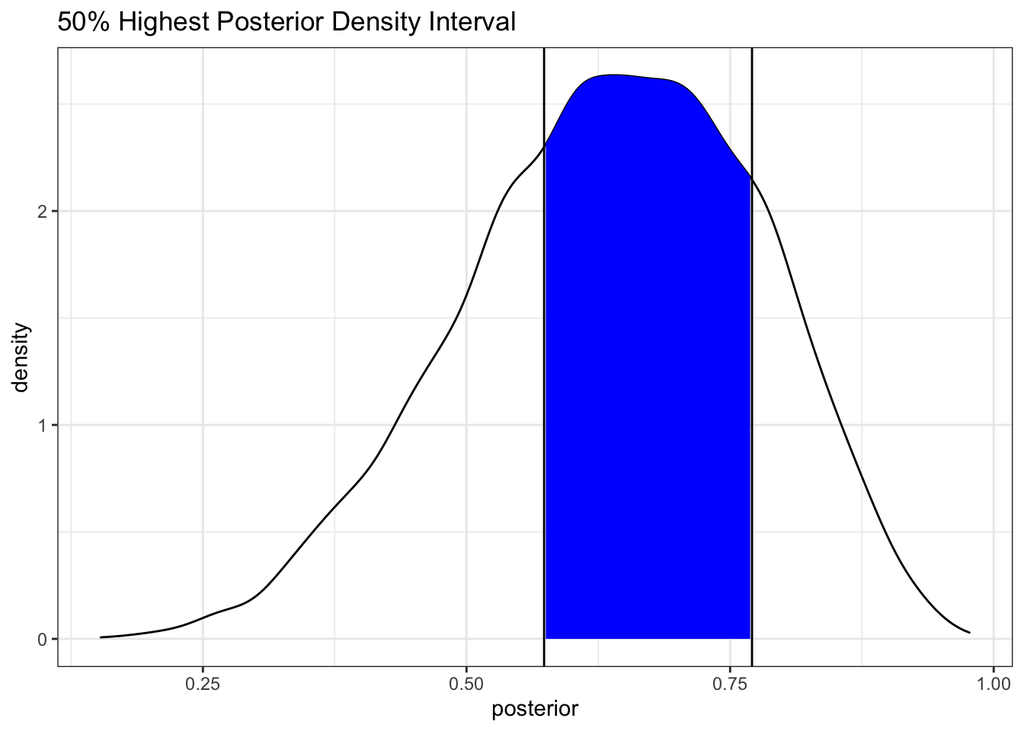

```r
pct_interval = HPDI( samples , prob=0.5 )
ggplot(data = post) + theme_bw() +
    geom_density(aes(x=posterior, y = ..density..), color = 'black') +
    geom_area(data = subset(df.dens, x >= pct_interval[1] & x <= pct_interval[2]),
              aes(x=x,y=y), fill = 'blue') +
    geom_vline(xintercept = pct_interval[1])  +
    geom_vline(xintercept = pct_interval[2])  +
    ggtitle('50% Highest Posterior Density Interval')
```

Now let us try to compute some point estimates. A common one to report is the mode of the aposterior estimate It’s easy to calculate

```r
p_grid[which.max(posterior)]
```

```
## [1] 0.6666667
```

Or from samples from the posterior

```r
rethinking::chainmode(samples, adj = 0.01)
```

```
## [1] 0.6433692
```

But we could just as well use the mean or the median

A principled way to choice which point estimate is using a loss function. Different loss functions will imply different point estimates

Let’s say we decide to make a loss function where the further away from the correct value we are, the worse The point estimate that maximizes that is the median of the posterior distribution

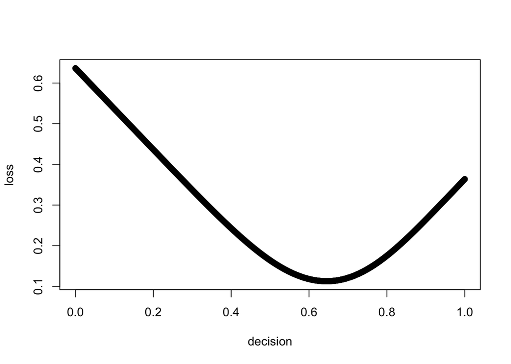

```r
decision = seq(from = 0 , to = 1, by = 0.001)

loss = purrr::map(decision,  ~ sum(posterior * abs(.x - p_grid))) %>% purrr::simplify()
plot(decision,loss)
```

```r
p_grid[which.min(loss)]
```

```
## [1] 0.6456456
```

```r
median(samples)
```

```
## [1] 0.6436436
```

In order to pick a point estimate, we need to define our loss function first.

## 3.3. Sampling to simulate prediction

1. We can use sampling to design and understand what kinds of values our model is generating.
2. We can use sampling to check that our model is working correctly
3. We can use sampling to ensure that our software fitting working properly
4. This can help use design future experiments
5. Predictions about the future

### Dummy data and the posterior predictive distribution

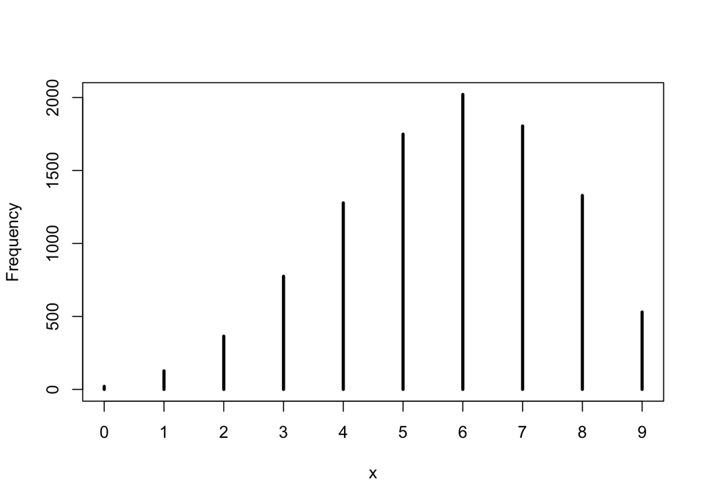

```r
w <- rbinom( 1e4 , size=9 , prob=samples )
simplehist(w)
```

# Chapter 3 Questions

```r
p_grid <- seq( from=0 , to=1 , length.out=1000 )
prior <- rep( 1 , 1000 )
likelihood <- dbinom( x = 6 , size=9 , prob=p_grid )
question_post <- likelihood * prior
question_post <- question_post / sum(question_post)
set.seed(100)
question_samples <- sample( p_grid , prob=question_post , size=1e4 , replace=TRUE )

question_post = tibble(posterior_samples = question_samples)
x.dens <- density(question_post$posterior_samples)
df.dens <- data.frame(x = x.dens$x, y = x.dens$y)
```

## 3 - E1

How much posterior probability lies below p = 0.2?

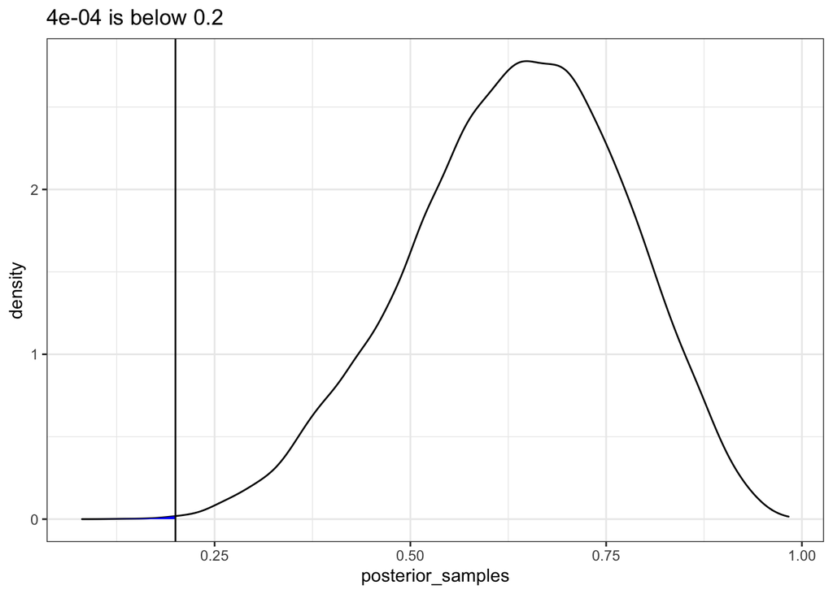

```r
# new code is below
cutoff = 0.2

post_below = sum(question_samples < cutoff) / 1e4

ggplot(data = question_post) + theme_bw() +
    geom_density(aes(x=posterior_samples, y = ..density..), color = 'black') +
    geom_area(data = subset(df.dens, x <= cutoff),
              aes(x=x,y=y), fill = 'blue') +
    geom_vline(xintercept = cutoff) +
    ggtitle(glue::glue("{post_below} is below {cutoff}"))
```

## 3 - E2

How much posterior probability lies above p = 0.8?

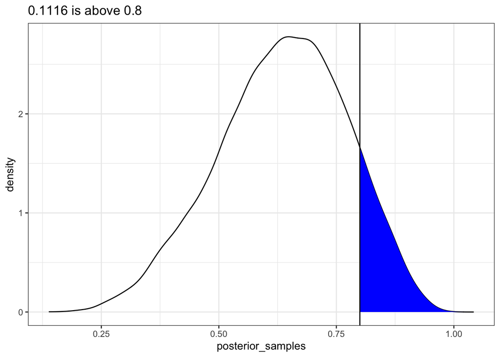

```r
# new code is below
cutoff = 0.8
post_below = sum(question_samples > cutoff) / 1e4



ggplot(data = question_post) + theme_bw() +
    geom_density(aes(x=posterior_samples, y = ..density..), color = 'black') +
    geom_area(data = subset(df.dens, x >= cutoff),
              aes(x=x,y=y), fill = 'blue') +
    geom_vline(xintercept = cutoff) +
    ggtitle(glue::glue("{post_below} is above {cutoff}"))
```

## 3 - E3

How much posterior probability lies between p = 0.2 and p = 0.8?

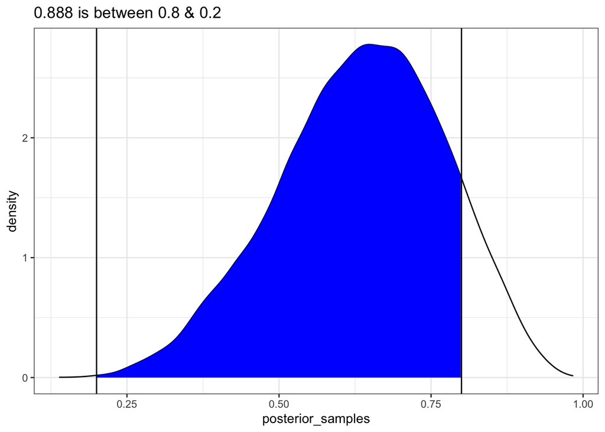

```r
# new code is below
cutoff_up = 0.8
cutoff_down = 0.2
post_below = (sum(question_samples <cutoff_up & question_samples > cutoff_down))/ 1e4


ggplot(data = question_post) +
    theme_bw() +
    geom_density(aes(x=posterior_samples, y = ..density..), color = 'black') +
    geom_area(data = subset(df.dens, x <= cutoff_up & x >= cutoff_down),
              aes(x=x,y=y), fill = 'blue') +
    geom_vline(xintercept = cutoff_up) +
    geom_vline(xintercept = cutoff_down) +
    ggtitle(glue::glue("{post_below} is between {cutoff_up} & {cutoff_down}"))
```

## 3 - E4

20% of the posterior probability lies below which value of p?

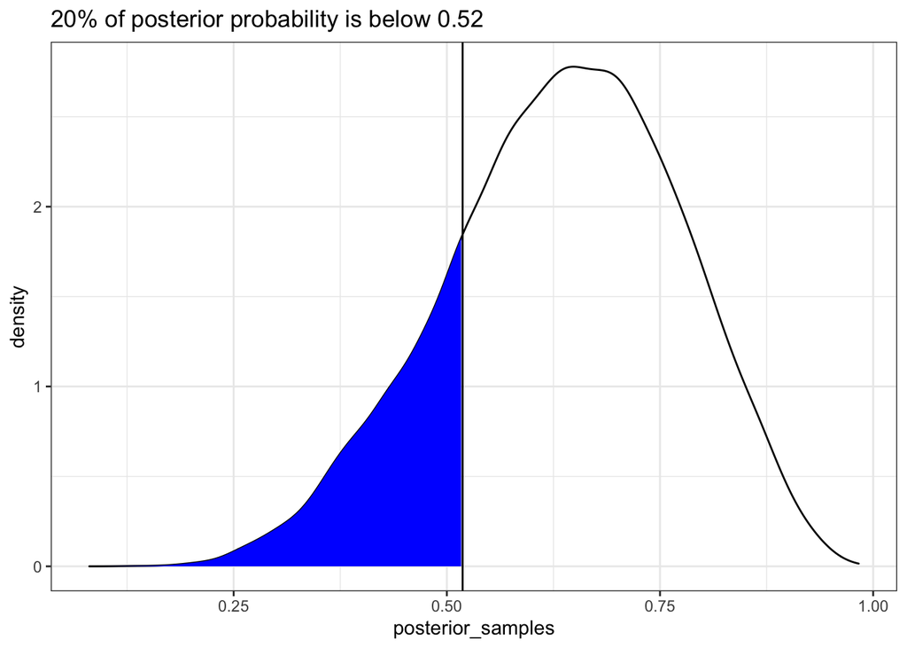

```r
pct_interval =PI( question_samples , prob=0.60)
ggplot(data = question_post) + theme_bw() +
    geom_density(aes(x=posterior_samples, y = ..density..), color = 'black') +
    geom_area(data = subset(df.dens, x <= pct_interval[1]),
              aes(x=x,y=y), fill = 'blue') +
    geom_vline(xintercept = pct_interval[1])  +
    ggtitle(glue::glue("20% of posterior probability is below {round(pct_interval[1],2)}"))
```

## 3 - E5

20% of the posterior probability lies above which value of p?

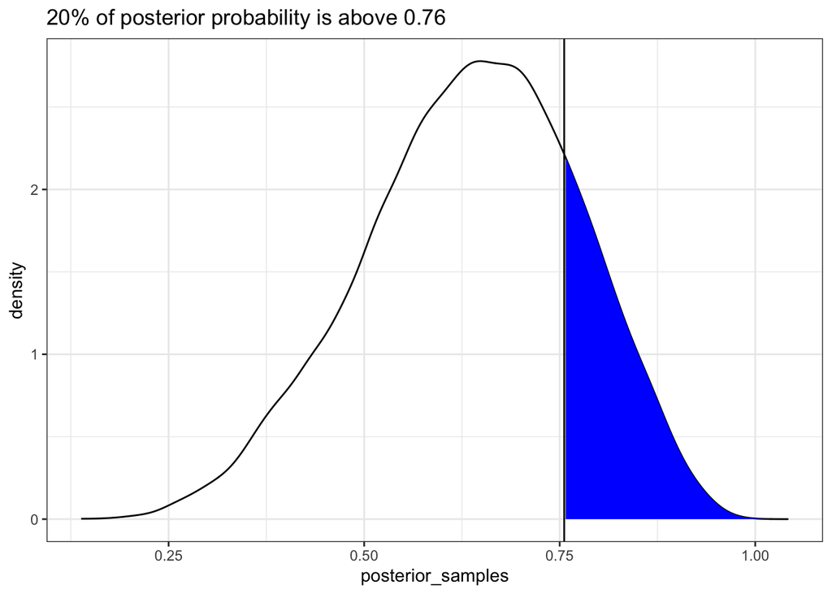

```r
pct_interval =PI( question_samples , prob=0.60)

ggplot(data = question_post) + theme_bw() +
    geom_density(aes(x=posterior_samples, y = ..density..), color = 'black') +
    geom_area(data = subset(df.dens, x >= pct_interval[2]),
              aes(x=x,y=y), fill = 'blue') +
    geom_vline(xintercept = pct_interval[2])  +
    ggtitle(glue::glue("20% of posterior probability is above {round(pct_interval[2],2)}"))
```

## 3 - E6

Which values of p contain the narrowest interval equal to 66% of the posterior probability?

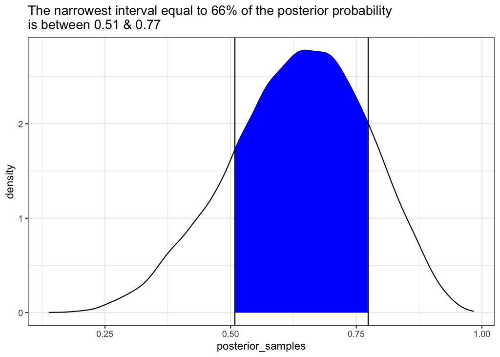

```r
pct_interval = HPDI( question_samples , prob=0.66)

cutoff_up = pct_interval[2]
cutoff_down = pct_interval[1]

ggplot(data = question_post) + theme_bw() +
    geom_density(aes(x=posterior_samples, y = ..density..), color = 'black') +
    geom_area(data = subset(df.dens, x <= cutoff_up & x >= cutoff_down),
              aes(x=x,y=y), fill = 'blue') +
    geom_vline(xintercept = cutoff_up) +
    geom_vline(xintercept = cutoff_down) +
    ggtitle(glue::glue("The narrowest interval equal to 66% of the posterior probability \n is between {round(cutoff_down,2)} & {round(cutoff_up,2)}"))
```

## 3 - E7

Which values of p contain 66% of the posterior probability, assuming equal posterior probability both below and above the interval?

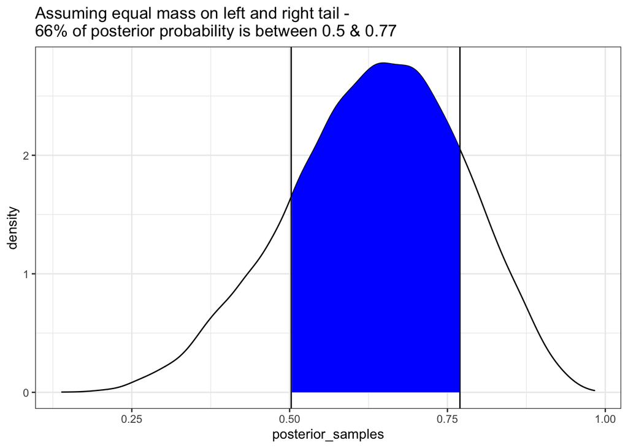

```r
pct_interval = PI( question_samples , prob=0.66)

cutoff_up = pct_interval[2]
cutoff_down = pct_interval[1]
ggplot(data = question_post) + theme_bw() +
    geom_density(aes(x=posterior_samples, y = ..density..), color = 'black') +
    geom_area(data = subset(df.dens, x <= cutoff_up & x >= cutoff_down),
              aes(x=x,y=y), fill = 'blue') +
    geom_vline(xintercept = cutoff_up) +
    geom_vline(xintercept = cutoff_down) +
    ggtitle(glue::glue("Assuming equal mass on left and right tail -  \n  66% of posterior probability is between {round(cutoff_down,2)} & {round(cutoff_up,2)}"))
```

## 3 - M1

Suppose the globe tossing data had turned out to be 8 water in 15 tosses. Construct the posterior distribution, using grid approximation. Use the same flat prior as before.

```r
p_grid <- seq( from=0 , to=1 , length.out=1000 )
prior <- rep( 1 , 1000 )
likelihood <- dbinom( x = 8 , size=15 , prob=p_grid )
question_post_medium <- likelihood * prior
question_post_medium <- question_post_medium / sum(question_post_medium)
```

## 3 - M2

Draw 10,000 samples from the grid approximation from above. Then use the samples to calculate the 90% HPDI for p.

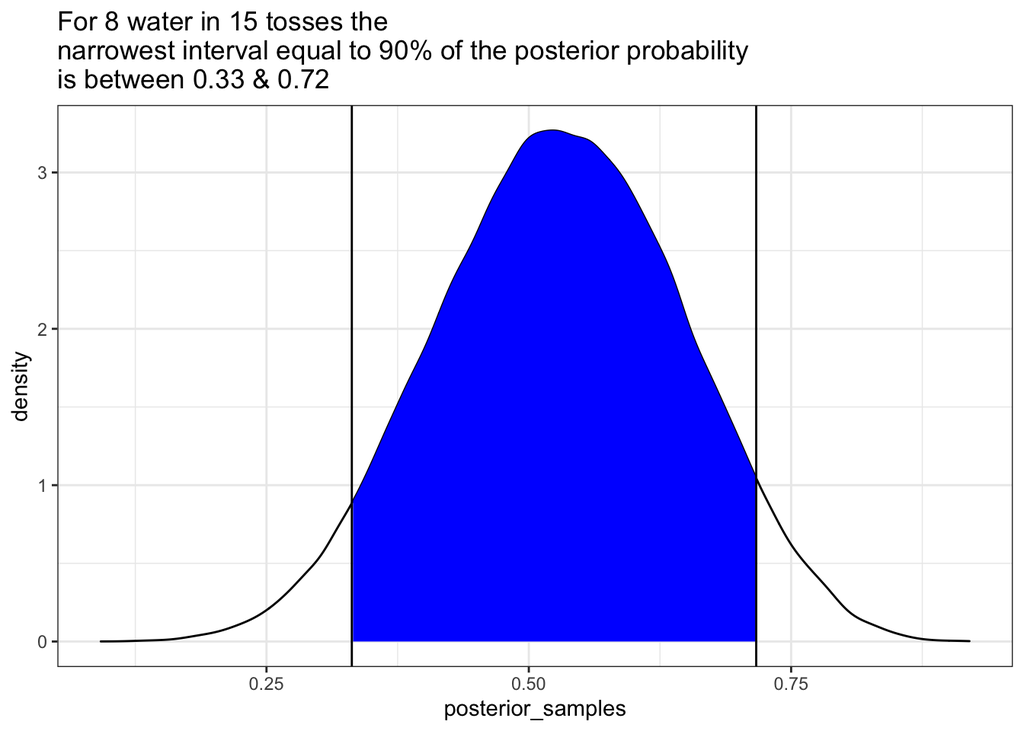

```r
set.seed(100)

question_samples_medium <- sample( p_grid , prob=question_post_medium , size=1e5 , replace=TRUE )

question_post_medium = tibble(posterior_samples = question_samples_medium)

x.dens <- density(question_post_medium$posterior_samples)
df.dens <- data.frame(x = x.dens$x, y = x.dens$y)


pct_interval = HPDI( question_samples_medium , prob=0.90)
cutoff_up = pct_interval[2]
cutoff_down = pct_interval[1]
flat_prior_plot = ggplot(data = question_post_medium) + theme_bw() +
    geom_density(aes(x=posterior_samples, y = ..density..), color = 'black') +
    geom_area(data = subset(df.dens, x <= cutoff_up & x >= cutoff_down),
              aes(x=x,y=y), fill = 'blue') +
    geom_vline(xintercept = cutoff_up) +
    geom_vline(xintercept = cutoff_down) +
    ggtitle(glue::glue("For 8 water in 15 tosses the \n narrowest interval equal to 90% of the posterior probability \n is between {round(cutoff_down,2)} & {round(cutoff_up,2)}"))
print(flat_prior_plot)
```

## 3 - M3

Construct a posterior predictive check for this model and data. This means simulate the distribution of samples, averaging over the posterior uncertainty in p. What is the probability of observing 8 water in 15 tosses?

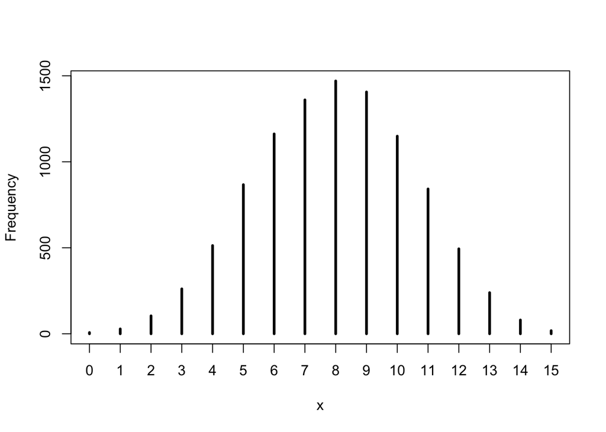

```r
#simulate the distribution of samples
posterior_predictive <- rbinom( 1e4 , size=15 , prob=question_post_medium$posterior_samples )
simplehist(posterior_predictive)
```

```r
sum(posterior_predictive == 8) / length(posterior_predictive)
```

```
## [1] 0.147
```

The probability of observing 8 water in 15 tosses is 0.147

## 3 - M4

using the posterior from 8/15 calculate the probability of 6 water in 9 tosses

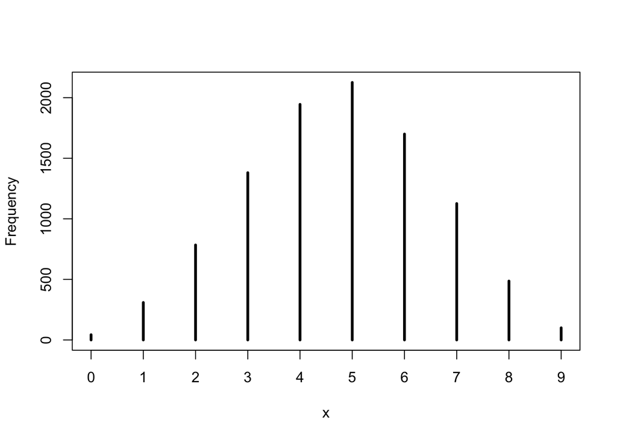

```r
#simulate the distribution of samples
posterior_predictive_69 <- rbinom( 1e4 , size=9 , prob=question_post_medium$posterior_samples )
simplehist(posterior_predictive_69)
```

```r
sum(posterior_predictive_69 == 6) / length(posterior_predictive_69)
```

```
## [1] 0.17
```

The probability of 6 water in 9 tosses is 0.17

## 3 - M5

Start over at M1 but now start with either prior that p > 0.5 and anything below is 0 - basically start knowing that the majority of the Earth is water.

```r
p_grid <- seq( from=0 , to=1 , length.out=1000 )
prior_majority_water <- rep( 1 , 1000 )
prior_majority_water[which(p_grid < 0.5)] = 0
likelihood_majority_water <- dbinom( x = 8 , size=15 , prob=p_grid )
posterior_majority_water <- likelihood_majority_water * prior_majority_water
posterior_majority_water <- posterior_majority_water / sum(posterior_majority_water)
```

Comparing the 90% HPDI for the uniform prior and the one where we know majority of the Earth is water

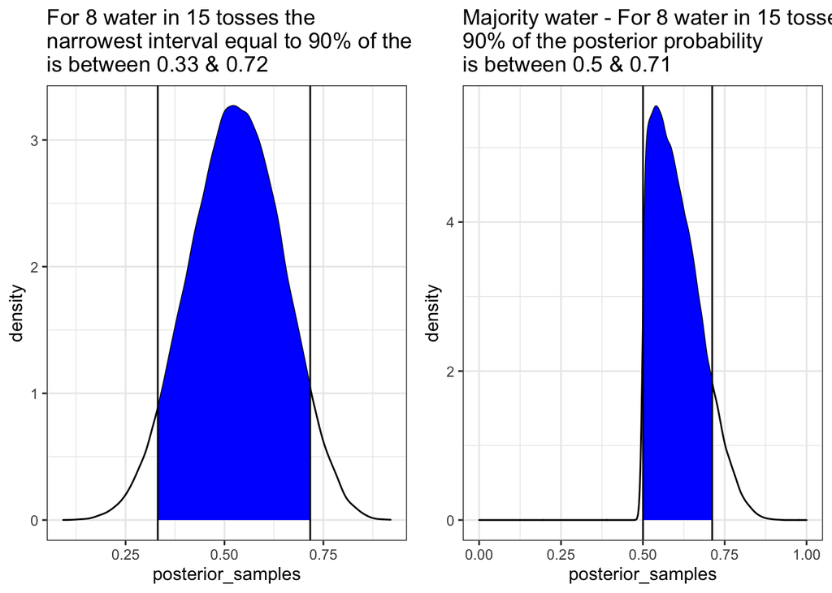

```r
set.seed(100)

question_samples_maj_water <- sample( p_grid , prob=posterior_majority_water , size=1e5 , replace=TRUE )

question_post_maj_water = tibble(posterior_samples = question_samples_maj_water)

x.dens <- density(question_post_maj_water$posterior_samples)
df.dens <- data.frame(x = x.dens$x, y = x.dens$y)


pct_interval = HPDI( question_samples_maj_water , prob=0.90)
cutoff_up = pct_interval[2]
cutoff_down = pct_interval[1]

maj_water_plot = ggplot(data = question_post_maj_water) + theme_bw() +
    geom_density(aes(x=posterior_samples, y = ..density..), color = 'black') +
    geom_area(data = subset(df.dens, x <= cutoff_up & x >= cutoff_down),
              aes(x=x,y=y), fill = 'blue') +
    geom_vline(xintercept = cutoff_up) +
    geom_vline(xintercept = cutoff_down) +
    ggtitle(glue::glue("Majority water - For 8 water in 15 tosses the \n 90% of the posterior probability \n is between {round(cutoff_down,2)} & {round(cutoff_up,2)}")) + xlim(0,1)

ggpubr::ggarrange(flat_prior_plot,maj_water_plot)
```

## 3 - M5 - Posterior predictive check

Construct a posterior predictive check for this model and data. This means simulate the distribution of samples, averaging over the posterior uncertainty in p. What is the probability of observing 8 water in 15 tosses?

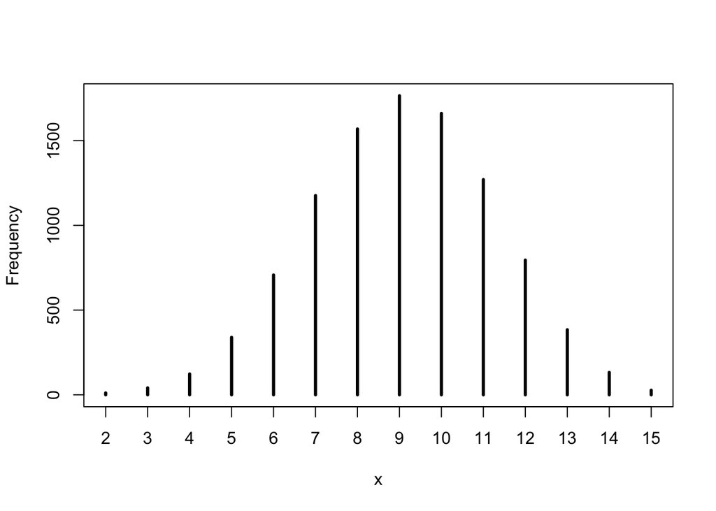

```r
#simulate the distribution of samples
posterior_predictive_maj <- rbinom( 1e4 , size=15 , prob=question_post_maj_water$posterior_samples )
simplehist(posterior_predictive_maj)
```

```r
sum(posterior_predictive_maj == 8) / length(posterior_predictive_maj)
```

```
## [1] 0.1569
```

Flat prior of observing 8 water in 15 tosses is 0.147

Knowing the Earth is mostly water observing 8 water in 15 tosses is 0.1569

## 3 - M5 - Calculate 6 in 9 from the sample

using the posterior from 8/15 calculate the probability of 6 water in 9 tosses

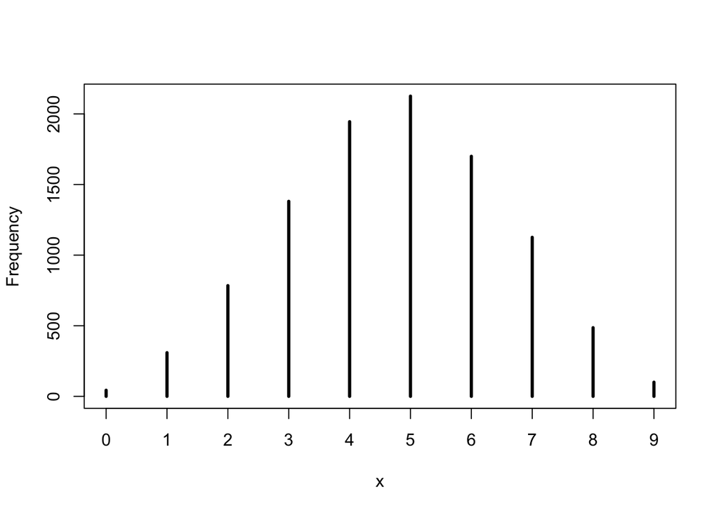

```r
#simulate the distribution of samples
posterior_predictive_69_maj <- rbinom( 1e4 , size=9 , prob=question_post_maj_water$posterior_samples )
simplehist(posterior_predictive_69)
```

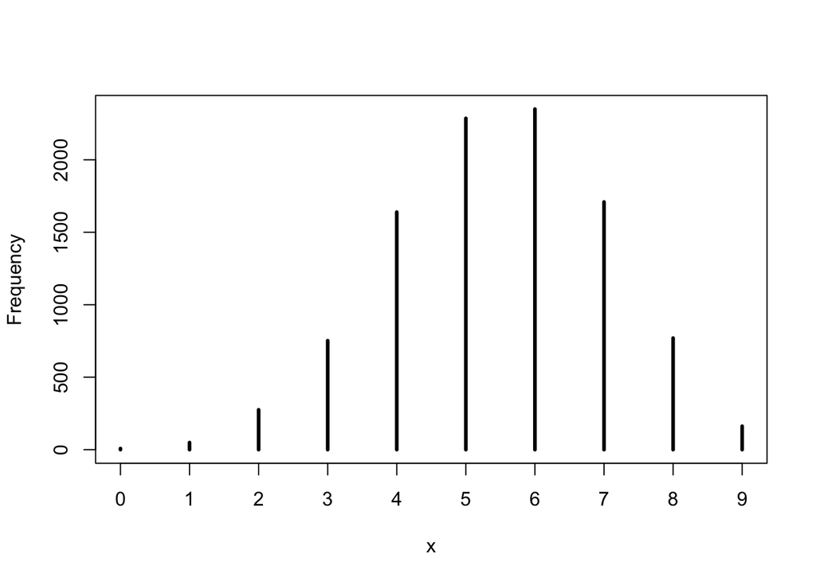

```r
simplehist(posterior_predictive_69_maj)
```

```r
sum(posterior_predictive_69_maj == 6) / length(posterior_predictive_69)
```

```
## [1] 0.235
```

Flat prior - probability of 6 water in 9 tosses is 0.17

Majority water prior - probability of 6 water in 9 tosses is 0.235

## 3 - M6

Suppose you want to estimate the Earth’s proportion of water very precisely. Specifically, you want the 99% percentile interval of the posterior distribution of p to be only 0.05 wide. This means the distance between the upper and lower bound of the interval should be 0.05. How many times will you have to toss the globe to do this?

```r
generate_intervals_by_num = function(num_samples = 10){
    set.seed(42)

    p_grid <- seq( from=0 , to=1 , length.out=1000 )
    prior <- rep( 1 , 1000 )

    tosses = rbinom(1,size = num_samples, prob = 0.7)

    likelihood <- dbinom( x = tosses , size=num_samples , prob=p_grid )

    looping_posterior <- likelihood * prior
    looping_posterior <- looping_posterior / sum(looping_posterior)

    sampled_loop <- sample( p_grid , prob=looping_posterior , size=1e5 , replace=TRUE )

    pct = HPDI(sampled_loop,prob = 0.99)
    browser()
    width = abs(pct[2] - pct[1])

    return(abs(width - 0.05))
}
```

## 3 - H1

Introduction. The practice problems here all use the data below. These data indicate the gender (male=1, female=0) of officially reported first and second born children in 100 two-child families.

```r
birth1 <- c(1,0,0,0,1,1,0,1,0,1,0,0,1,1,0,1,1,0,0,0,1,0,0,0,1,0,
0,0,0,1,1,1,0,1,0,1,1,1,0,1,0,1,1,0,1,0,0,1,1,0,1,0,0,0,0,0,0,0,
1,1,0,1,0,0,1,0,0,0,1,0,0,1,1,1,1,0,1,0,1,1,1,1,1,0,0,1,0,1,1,0,
1,0,1,1,1,0,1,1,1,1)
birth2 <- c(0,1,0,1,0,1,1,1,0,0,1,1,1,1,1,0,0,1,1,1,0,0,1,1,1,0,
1,1,1,0,1,1,1,0,1,0,0,1,1,1,1,0,0,1,0,1,1,1,1,1,1,1,1,1,1,1,1,1,
1,1,1,0,1,1,0,1,1,0,1,1,1,0,0,0,0,0,0,1,0,0,0,1,1,0,0,1,0,0,1,1,
0,0,0,1,1,1,0,0,0,0)


birth_tibble = data.table::data.table(birth1,birth2)
```

Using grid approximation, compute the posterior distribution for the probability of a birth being a boy. Assume a uniform prior probability. Which parameter value maximizes the posterior probability?

```r
p_grid <- seq( from=0 , to=1 , length.out=1000 )
prior <- rep( 1 , 1000 )
likelihood_boy <- dbinom( x = 111 , size=200 , prob=p_grid )
hard_posterior <- likelihood_boy * prior
hard_posterior <- hard_posterior / sum(hard_posterior)
```

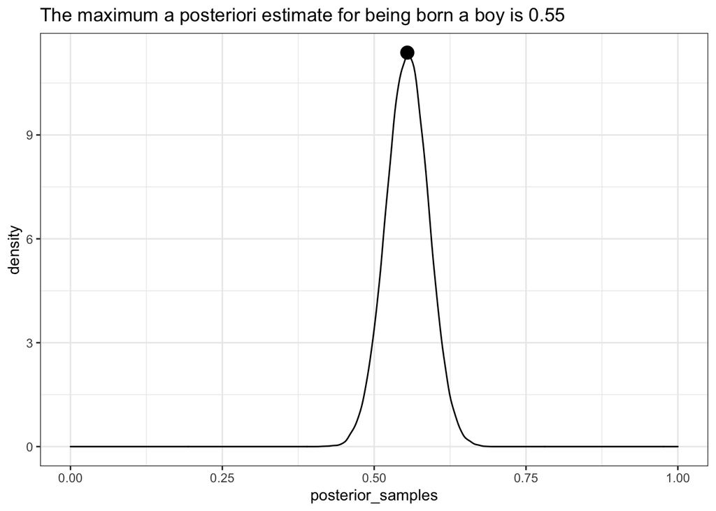

```r
hard_posterior_samples <- sample( p_grid , prob=hard_posterior , size=1e5 , replace=TRUE )

hard_posterior_samples = tibble(posterior_samples = hard_posterior_samples)

x.dens <- density(hard_posterior_samples$posterior_samples)
df.dens <- data.frame(x = x.dens$x, y = x.dens$y)

point = tibble(x = p_grid[which.max(hard_posterior)], y = max(density(hard_posterior_samples$posterior_samples)$y))

ggplot(data = hard_posterior_samples) + theme_bw() +
    geom_density(aes(x=posterior_samples, y = ..density..), color = 'black') +
    geom_point(data = point, aes(x = x, y = y),size = 4) +
    xlim(0,1) +
    ggtitle(glue::glue("The maximum a posteriori estimate for being born a boy is {round(p_grid[which.max(hard_posterior)],2)}"))
```

## 3 - H2

Using the sample function, draw 10,000 random parameter values from the posterior distri- bution you calculated above. Use these samples to estimate the 50%, 89%, and 97% highest posterior density intervals.

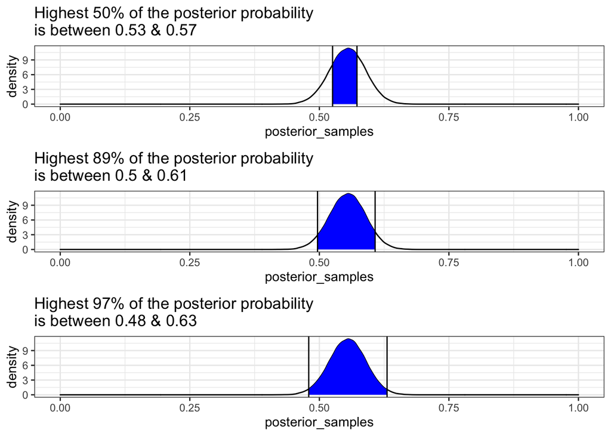

```r
create_hpdi_plot = function(prob,posterior_samples_df){
    x.dens <- density(posterior_samples_df$posterior_samples)
    df.dens <- data.frame(x = x.dens$x, y = x.dens$y)

    pct_interval = HPDI(posterior_samples_df$posterior_samples , prob=prob)

    cutoff_up = pct_interval[2]
    cutoff_down = pct_interval[1]

    hpdi_graph = ggplot(data = posterior_samples_df) + theme_bw() +
        geom_density(aes(x=posterior_samples, y = ..density..), color = 'black') +
        geom_area(data = subset(df.dens, x <= cutoff_up & x >= cutoff_down),
                  aes(x=x,y=y), fill = 'blue') +
        geom_vline(xintercept = cutoff_up) +
        geom_vline(xintercept = cutoff_down) +
        xlim(0,1) +
        ggtitle(glue::glue("Highest {prob * 100}% of the posterior probability \n is between {round(cutoff_down,2)} & {round(cutoff_up,2)}"))

    return(hpdi_graph)
}

plts = purrr::map(c(0.5,0.89,0.97),create_hpdi_plot,hard_posterior_samples)
ggpubr::ggarrange(plotlist =  plts,nrow = 3)
```

## 3 - H3

Use rbinom to simulate 10,000 replicates of 200 births. Compare the distribution of predicted numbers to actual count. Does it look like the model fits the data well - does the distribution of predictions include the actual observation as a central, likely outcome?

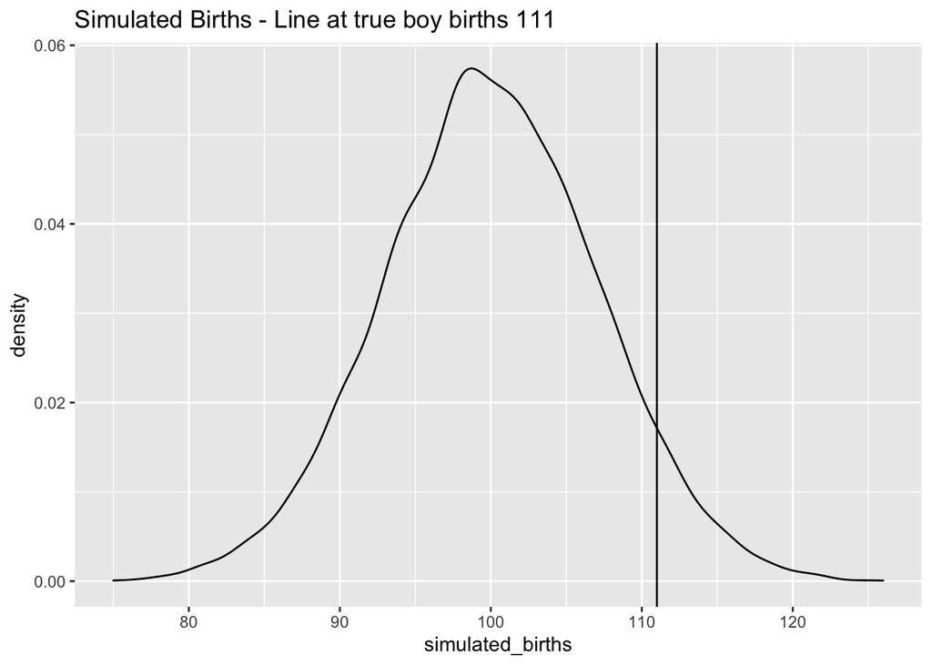

```r
simulated_births <- rbinom( 1e4 , size=200,prob = 0.5)
ggplot() +
    geom_density(aes(x = simulated_births)) +
    geom_vline(xintercept =  111) +
    ggtitle("Simulated Births - Line at true boy births 111")
```

## 3 - H4

Now compare only to the counts of first borns

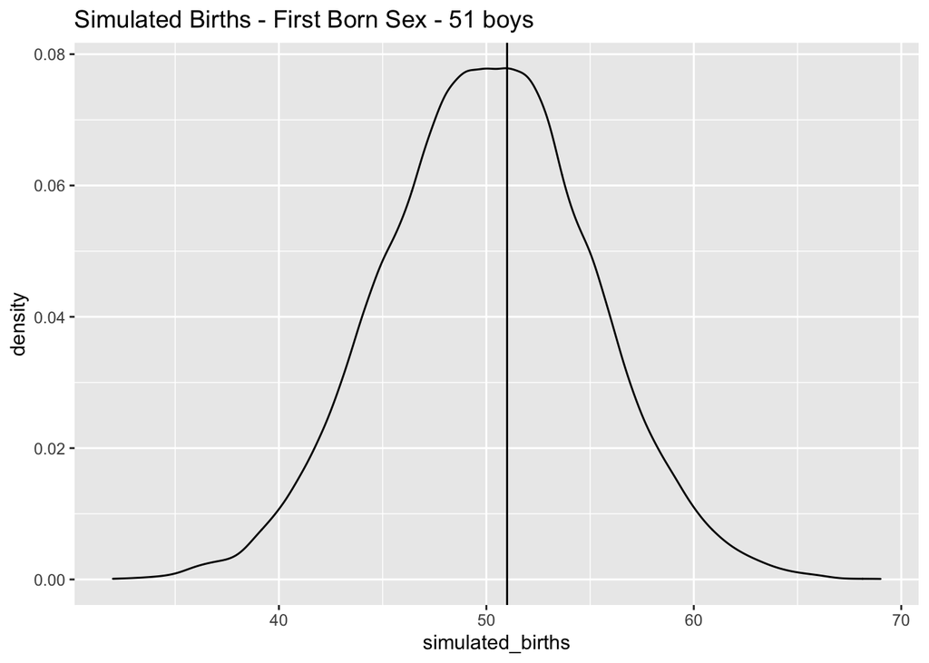

```r
simulated_births <- rbinom( 1e4 , size=100,prob = 0.5)
ggplot() +
    geom_density(aes(x = simulated_births)) +
    geom_vline(xintercept =  51) +
    ggtitle("Simulated Births - First Born Sex - 51 boys")
```

## 3 - H5

The model assumes independence between birth order and baby sex. But is this true? Focus on the sex of the second born after a girl.

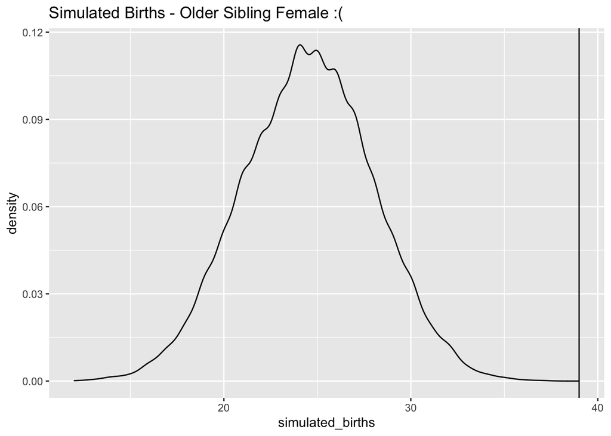

```r
simulated_births <- rbinom( 1e4 , size=49,prob = 0.5)
ggplot() +
    geom_density(aes(x = simulated_births)) +
    geom_vline(xintercept =  39) +
    ggtitle(glue::glue("Simulated Births - Older Sibling Female :( "))
```